# Web Scraping & Text cleaning

Hamza Saadi

[figure not shown]

```r
library(tidyverse) #data manipulation and visualization
library(rvest)
```

## website introduction:

Lkeria website contain alot of articles that we may find useful to analyse.

With the first look in `Actualité`section we find different articles with different topics.

[figure not shown]

As we select one article, we see a page like this one bellow, contain different informations.

[figure not shown]

## Scrap the data from LKERIA web site.

This is an exemple how source code look like:

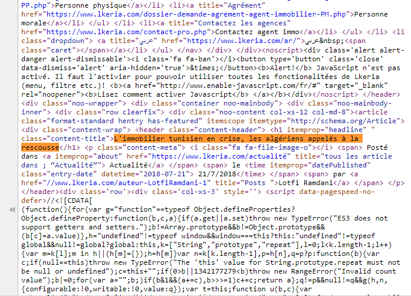

Here we’re going to create a function to scrap all avaible links from Lkeria page’s.

```r
Scrap_links<- function(url){
  url %>%
    read_html()%>%
    html_nodes("a")%>%
    html_attr("href")%>%
    unique()
}
```

Since all articles Lkeria website have one root, wiche is:

```r
url <- "https://www.lkeria.com/actualité-P"  # The root Link.

links <- lapply(paste0(url,                  # list_apply function "Scrap_link"
                       c(1:72)),             # on all avaible "Actualité"
                Scrap_links)                 # links on Lkeria website  to return list of vectors of links
```

Let’s take look at links:

```r
head(links[[1]],10)                       # print first 5 Observations
```

```
##  [1] "https://www.lkeria.com/login.php"
##  [2] "https://www.lkeria.com/recherche.php"
##  [3] "https://www.lkeria.com/"
##  [4] "https://www.lkeria.com/annonces/immobilier/location"
##  [5] "https://www.lkeria.com/annonces/immobilier/location/appartement"
##  [6] "https://www.lkeria.com/annonces/immobilier/location/villa"
##  [7] "https://www.lkeria.com/annonces/immobilier/location/niveau-villa"
##  [8] "https://www.lkeria.com/annonces/immobilier/location/studio"
##  [9] "https://www.lkeria.com/annonces/immobilier/location/local"
## [10] "https://www.lkeria.com/annonces/immobilier/vacances"
```

Since it’s list of vectors of links, we need to find links with a specific pattern.

```r
#Define indices to use it later on.
indices <- lapply(X = links,               # use list_apply function on links
                  FUN = grep,              # with grep function
                  pattern = "^actualité/") # to return all indicies of character that start with  "actualité/"

head(indices[[1]])                         # indicies of first link on first webpage
```

```
## [1] 35 37 39 40 42 43
```

Now, that we have all links, and indicies needed let’s wrap it up:

```r
# Function to combine list and it's indicies:

scrap_lkeria <- function(x,l,i){         # x: page range, l: list, i: indices
  return(l[[x]][i[[x]]])

}

Thelinks <- sapply(c(1:72),             # application simplify_apply on scrap_lkeria
                   FUN =scrap_lkeria,   # to return list of needed links.
                   USE.NAMES = F,
                   l=links,
                   i=indices)%>%
  unlist(use.names = F)                 # to transfer it from list of vectors to charachter vector.

head(Thelinks)
```

```
## [1] "actualité/logement/que-VA-contenir-le-contrat-entre-aadl-enpi-et-souscripteurs"
## [2] "actualité/logement/enfin-des-contrats-pour-le-lpp-et-l-aadl"
## [3] "actualité/aadl/recours-aadl2-17-pourcent-seulement-des-recours-acceptes"
## [4] "actualité/aadl/lancement-operation-choix-sites-aadl2-31-wilayas"
## [5] "actualité/aadl/choix-site-aadl-31-wilayas"
## [6] "actualité/aadl/lancement-5300-logements-promotionnels-aides-lpa"
```

So far so good, but we still need to add strings in order to be a usefull links.

```r
#Easy Step
Thelinks <- paste0("https://www.lkeria.com/",Thelinks)

head(Thelinks)
```

```
## [1] "https://www.lkeria.com/actualité/logement/que-VA-contenir-le-contrat-entre-aadl-enpi-et-souscripteurs"
## [2] "https://www.lkeria.com/actualité/logement/enfin-des-contrats-pour-le-lpp-et-l-aadl"
## [3] "https://www.lkeria.com/actualité/aadl/recours-aadl2-17-pourcent-seulement-des-recours-acceptes"
## [4] "https://www.lkeria.com/actualité/aadl/lancement-operation-choix-sites-aadl2-31-wilayas"
## [5] "https://www.lkeria.com/actualité/aadl/choix-site-aadl-31-wilayas"
## [6] "https://www.lkeria.com/actualité/aadl/lancement-5300-logements-promotionnels-aides-lpa"
```

```r
print(paste0("Number of links: ",length(Thelinks)))
```

```
## [1] "Number of links: 1066"
```

Getting links it was the easy part, now let’s start scraping the articles using `Thelinks`, But first of all we need to define patterns to use in scraping and subsutting with *Regular expression*.  
### Comments:

- `<.*?>` To remove all HTML tags.
- `http[^[:space:]]*` To remove all html links that start with http or https.
- `\\(adsbygoogle=window.adsbygoogle\\|\\|\\[\\]\\).push\\(\\{\\}\\);` To remove google ads.
- `\\[.*?\\]` in case there are tags like `[caption][/captio]` etc…
- Also removing names of writers since there are few names mentioned bellow.

```r
the_pattern <- paste("<.*?>",
                      "http[^[:space:]]*",
                      "\\(adsbygoogle=window.adsbygoogle\\|\\|\\[\\]\\).push\\(\\{\\}\\);",
                      "\\[.*?\\]",
                     "Idir Zidane",
                     "Izouaouen Noreddine",
                     "Lotfi Ramdani",
                     "Nabil Walid",
                     "Rédaction Lkeria",
                     "Walid Nsaibia",
                      sep = "|")
# Define scrap_articles function:
Scrap_articles <- function(url){
      html <- url %>%                              # creat HTML page from URL input
        read_html()

      title <- html%>%                             # Get title from
        html_nodes(".content-title")%>%            # .content-title node
        html_text()%>%                             # transform from html to text
        iconv(from = "UTF-8","latin1", sub="")%>%  # remove all character that's not latin1
        str_trim()                                 # remove leading and trailing white spaces

      raw_info <- html%>%                          # Get all avaible text from
        html_nodes(".content-meta")%>%             # .content-meta node
        html_text()%>%                             # transform from html to text
        str_split(pattern = "le|par")              # split to a list based on pattern to define date/writer

      date <- raw_info[[1]][2] %>%                 # get date
                          str_trim()               # remove leading and trailing white spaces

      writer <- raw_info[[1]][3] %>%               # get writer name's
                    str_trim()                     # remove leading and trailing white spaces

      intro  <- html%>%                            # get introduction section from
        html_nodes(".col-xs-9")%>%                 # .col-xs-9 node
        html_text()%>%                             # transform from html to text
        str_replace_all(pattern =the_pattern ,     # remove unwanted pattern and
                        replacement = " ")%>%      # replace with white space
        iconv(from = "UTF-8","latin1", sub="")%>%  # remove all character that's not latin1
        str_trim()                                 # remove leading and trailing white spaces



      if((length(intro) == 0) ||                     # Check in case intro is Empty
         ( str_detect(intro,"Article modifié le") || # Check in case intro is the same as Text(further var)
           nchar(intro)<=1)){                        # Check in case intro is only white space
        intro <- NA                                  # Force intro to be NA
      }

      text <- (html%>%
        html_nodes(".content")%>%                    # Select node .content from HTML page
        html_text() %>%                              # get the text
        str_split(pattern = "Article modifié le"))[[1]][1] %>% # Split based on patter retrive text
        str_replace_all(pattern = the_pattern,replacement = " ")%>% # remove unwated pattern
        iconv(from = "UTF-8","latin1", sub="")%>%    # remove all character that's not latin1
        str_trim()                                   # remove leading and trailing white spaces

      return(c(title,date,writer,intro,text,url))    # retun all retrieved var
}

secure_scrap <- possibly(.f = Scrap_articles,             # Creat secure funtion to return NAs
                        otherwise = c(NA,NA,NA,NA,NA,NA),# in case there is dead links
                        quiet = T)                       # skip warnings or msg.
```

After defining the function needed, let’s start the process to scrap the data:

```r
start.time <- Sys.time()                                    # Start time excution

DF <- Thelinks %>%
  map(.f = secure_scrap) %>%                                # map var Thelinks as input to scure_scrap
  map(function(x) data.frame(t(x),stringsAsFactors = F))%>% # map list output from previous map to creat  DFs
  bind_rows()                                               # tansform list of Data frames to one DF

names(DF) <- c("Title",                                     # Define column names
               "Publication.Date",
               "Writer",
               "Introduction",
               "Text",
               "Link")

end.time <- Sys.time()                                     # Stop time excution

time.taken <- end.time - start.time                        # difference

print(time.taken)
```

```
## Time difference of 18.40662 mins
```

```r
glimpse(DF)
```

```
## Observations: 1,066
## Variables: 6
## $ Title            <chr> "Que va contenir le contrat préliminaire lian...
## $ Publication.Date <chr> "10/10/2018", "09/10/2018", "05/10/2018", "04...
## $ Writer           <chr> "Lotfi Ramdani", "Rédaction Lkeria", "Rédacti...
## $ Introduction     <chr> "Reçu par le Ministre de l'Habitat, de l'Urba...
## $ Text             <chr> "Dans le cadre de l'enrichissement du débat s...
## $ Link             <chr> "https://www.lkeria.com/actualité/logement/qu...
```

```r
write.csv(x = DF,                  # Define var to store
          file = "ScapedFile.csv", # file name
          row.names = F)           # drop raw names
```

## Part Two: Data Cleaning & Manipulation

From the previous section we’ve got a complete data set of articles, but still has some NA’s, and uncleaned data.

```r
DF <- read.csv("ScapedFile.csv",               # Since it's small datasets we can use base function
               encoding = "latin1",            # "latin1" to be able to read charachters with "accents"
               stringsAsFactors = F)           # Drop factors Option

glimpse(DF)                                    # take a glimpse
```

```
## Observations: 1,066
## Variables: 6
## $ Title            <chr> "Que va contenir le contrat préliminaire lian...
## $ Publication.Date <chr> "10/10/2018", "09/10/2018", "05/10/2018", "04...
## $ Writer           <chr> "Lotfi Ramdani", "Rédaction Lkeria", "Rédacti...
## $ Introduction     <chr> "Reçu par le Ministre de l'Habitat, de l'Urba...
## $ Text             <chr> "Dans le cadre de l'enrichissement du débat s...
## $ Link             <chr> "https://www.lkeria.com/actualité/logement/qu...
```

### Comments:

Now, we need to some manipulation and cleaning:

- Transform `Publication.Date` to Date format to be useful.
- Remove rows with NA values in `Publication.Date` var.
- Creat a variable that take `Intro` if `Text` == NA else take `Text`.
- Extract New variable `Type` from `Link` using *regular expression*.

```r
DF$Publication.Date <- DF$Publication.Date %>%      # Transform Publication.Date from
                        as.Date(format="%d/%m/%Y")  # Character to date type



DF <- DF[!is.na(DF$Publication.Date),]              # Select only rows that doesn't contain NA's

DF$Full.Text <- DF$Text                             # Creat Full.text Var similair to Text var

DF$Full.Text[is.na(DF$Full.Text)] <- DF$Introduction[is.na(DF$Full.Text)] # fill NA's Var.

DF$Full.Text<- DF$Full.Text %>%                   # Remove residue of HTML code
  str_replace_all("\\{[^\\}]+\\}|\\.[A-Za-z0-9_]+|#[#A-Za-z0-9_]+|\\W", " ")

sum(is.na(DF$Full.Text))                            # Check if there are NA's in Full.text var
```

```
## [1] 0
```

```r
DF$Type <- sapply(DF$Link,                          # Created new var Type from Link
                      FUN = function(x) strsplit(x,split = "/")[[1]][5], # custum function to select
                      USE.NAMES = F)                # remove row names.


DF <- DF %>%                                        # We removed Intro, Text, Link
  select(Title,Publication.Date,Writer,Full.Text,Type)


glimpse(DF)                                         # take glimpse
```

```
## Observations: 1,048
## Variables: 5
## $ Title            <chr> "Que va contenir le contrat préliminaire lian...
## $ Publication.Date <date> 2018-10-10, 2018-10-09, 2018-10-05, 2018-10-...
## $ Writer           <chr> "Lotfi Ramdani", "Rédaction Lkeria", "Rédacti...
## $ Full.Text        <chr> "Dans le cadre de l enrichissement du débat s...
## $ Type             <chr> "logement", "logement", "aadl", "aadl", "aadl...
```

```r
table(DF$Type)                                      # Count Different Obs in Type var
```

```
##
##         aadl architecture       banque          btp     cadastre
##          123            8            2            2            1
##     écologie     etranger   immobilier          jsi     logement
##            2            1           38            4          730
##          lpa          lpp       people    promotion       social
##           21           69            1           14            4
##  transaction    urbanisme
##           24            4
```

```r
write.csv(DF,"CleanedArticles.csv",row.names = F)      # always save your progress

Col_class <- sapply(DF,class,USE.NAMES = F)
```